# Traditional Survival Analysis

Ihona Maria Correa de Cabo

2025-04-24

Load the necessary libraries:

```r
# --- Survival Analysis Core Packages ---
library(survival)        # Kaplan-Meier, Cox models, parametric survival
library(flexsurv)        # Flexible parametric survival models
library(survcomp)        # Model evaluation (C-index, AUC)
library(survex)          # Explainability for survival models
library(pec)             # Brier scores and integrated Brier scores
library(riskRegression)  # Risk prediction, competing risks, model comparison

# --- Visualization and Reporting ---
library(survminer)       # Survival plots and diagnostics
library(ggplot2)         # Data visualization
library(gtsummary)       # Summary tables for statistical models
library(gt)              # Aesthetic tables

# --- Model Building and Utilities ---
library(caret)           # Machine learning workflows and model tuning
library(car)             # Regression diagnostics and validation
library(magrittr)        # Pipe operator (%>%)
```

```r
setwd("C:/Users/IhonaCorrea/Desktop/MASTER/MASTER_THESIS/survival_analysis_1")
```

This dataset contains people diagnosed from lung cancer that either died or survived from the disease. It contains the following variables: patient_id, NHC, sex, morphology, tobacco, age_group and time to event in different (in days, months and years). Variable death is a flag indicating if the patient died (1) or survived (0) at the end of follow-up.

```r
lung_data <- read.csv("df_lung_cancer.csv")
```

```r
head(lung_data)
```

```
##   patient_id      NHC sex     morphology tobacco age_group time_to_event_days
## 1          3 11734238   1       Squamous      No         5                  8
## 2          6 11943387   1       Squamous      No         4                265
## 3          8 12150847   2 Adenocarcinoma      No         4                829
## 4         12 12608694   1 Adenocarcinoma      No         4                152
## 5         22 13535175   1         Others      No         4                 28
## 6         46 13993625   1       Squamous      No         5               1773
##   time_to_event_months time_to_event_years death
## 1            0.2628337          0.02190281     1
## 2            8.7063655          0.72553046     1
## 3           27.2361396          2.26967830     1
## 4            4.9938398          0.41615332     1
## 5            0.9199179          0.07665982     1
## 6           58.2505133          4.85420945     1
```

```r
str(lung_data)
```

```
## 'data.frame':    1451 obs. of  10 variables:
##  $ patient_id          : int  3 6 8 12 22 46 53 54 67 83 ...
##  $ NHC                 : int  11734238 11943387 12150847 12608694 13535175 13993625 14035904 14045754 14107038 14136656 ...
##  $ sex                 : int  1 1 2 1 1 1 2 1 1 1 ...
##  $ morphology          : chr  "Squamous" "Squamous" "Adenocarcinoma" "Adenocarcinoma" ...
##  $ tobacco             : chr  "No" "No" "No" "No" ...
##  $ age_group           : int  5 4 4 4 4 5 5 3 3 3 ...
##  $ time_to_event_days  : int  8 265 829 152 28 1773 1429 555 3525 3530 ...
##  $ time_to_event_months: num  0.263 8.706 27.236 4.994 0.92 ...
##  $ time_to_event_years : num  0.0219 0.7255 2.2697 0.4162 0.0767 ...
##  $ death               : int  1 1 1 1 1 1 1 1 0 0 ...
```

```r
summary(lung_data)
```

```
##    patient_id         NHC                sex         morphology
##  Min.   :    3   Min.   :    7688   Min.   :1.000   Length:1451
##  1st Qu.: 5766   1st Qu.:13990562   1st Qu.:1.000   Class :character
##  Median :24689   Median :14137506   Median :1.000   Mode  :character
##  Mean   :24877   Mean   :14043237   Mean   :1.227
##  3rd Qu.:42298   3rd Qu.:14253406   3rd Qu.:1.000
##  Max.   :57164   Max.   :20071160   Max.   :2.000
##    tobacco            age_group     time_to_event_days time_to_event_months
##  Length:1451        Min.   :1.000   Min.   :   1.0     Min.   :  0.03285
##  Class :character   1st Qu.:3.000   1st Qu.:  80.0     1st Qu.:  2.62834
##  Mode  :character   Median :3.000   Median : 333.0     Median : 10.94045
##                     Mean   :3.334   Mean   : 742.8     Mean   : 24.40386
##                     3rd Qu.:4.000   3rd Qu.:1165.0     3rd Qu.: 38.27515
##                     Max.   :5.000   Max.   :3647.0     Max.   :119.81930
##  time_to_event_years     death
##  Min.   :0.002738    Min.   :0.0000
##  1st Qu.:0.219028    1st Qu.:0.0000
##  Median :0.911704    Median :1.0000
##  Mean   :2.033655    Mean   :0.7443
##  3rd Qu.:3.189596    3rd Qu.:1.0000
##  Max.   :9.984942    Max.   :1.0000
```

```r
table(lung_data$sex, lung_data$death)
```

```
##
##       0   1
##   1 258 864
##   2 113 216
```

```r
addmargins(table(lung_data$age_group, lung_data$death))
```

```
##
##          0    1  Sum
##   1     30   51   81
##   2     86  183  269
##   3    133  305  438
##   4     97  314  411
##   5     25  227  252
##   Sum  371 1080 1451
```

```r
# Convert numerical variables to factors with labels
lung_data <- lung_data %>%
  mutate(
    sex = factor(sex, levels = c(1, 2), labels = c("Male", "Female")),
    age_group = factor(age_group, levels = c(1, 2, 3, 4, 5),
                       labels = c("<50", "50-59", "60-69", "70-79", ">80"))
  )
```

# Non-parametric estimation: Kaplan Meier

First we create the surv object:

```r
surv_obj_os <- Surv(time = lung_data$time_to_event_months, event = lung_data$death) # For OS
```

```r
surv_obj_os_years <- Surv(time = lung_data$time_to_event_years, event = lung_data$death) # For OS
```

```r
# Kaplan-Meier estimator
km_fit <- survfit(surv_obj_os ~ 1)  # ~1 means overall survival without grouping
km_fit_years <- survfit(surv_obj_os_years ~ 1)
```

```r
# Extract and print the median survival time
summary(km_fit)$table
```

```
##     records       n.max     n.start      events       rmean   se(rmean)
## 1451.000000 1451.000000 1451.000000 1080.000000   36.708156    1.276731
##      median     0.95LCL     0.95UCL
##   10.940452    9.987680   12.747433
```

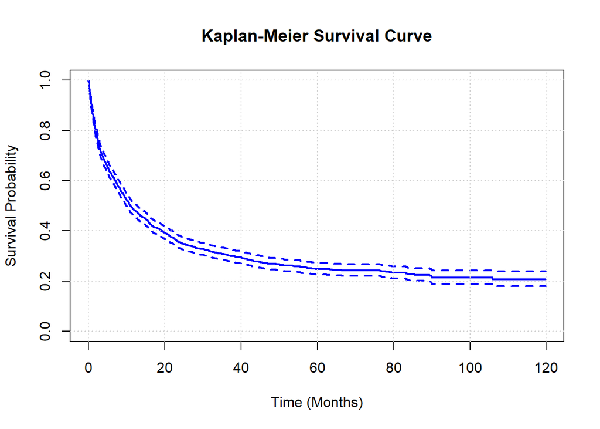

```r
# Basic Kaplan-Meier survival plot
plot(km_fit, xlab = "Time (Months)", ylab = "Survival Probability",
     main = "Kaplan-Meier Survival Curve", col = "blue", lwd = 2)
grid()
```

```r
# Month when the last patient died
max(lung_data$time_to_event_months[lung_data$death == 1])
```

```
## [1] 105.922
```

```r
# Number of patients alive at the end of the study
sum(lung_data$death == 0 & lung_data$time_to_event_months == max(lung_data$time_to_event_months))
```

```
## [1] 1
```

```r
# Summary at specific times
summary(km_fit_years, times = c(1, 3, 5, 10))  # Extract survival probabilities at 1, 3, and 5 years
```

```
## Call: survfit(formula = surv_obj_os_years ~ 1)
##
##  time n.risk n.event survival std.err lower 95% CI upper 95% CI
##     1    701     750    0.483  0.0131        0.458        0.510
##     3    382     252    0.307  0.0122        0.284        0.332
##     5    199      62    0.249  0.0120        0.226        0.273
```

Let’s fit the Kaplan-meier estimators for different groups:

```r
# Treat these variables as factors
lung_data$sex <- as.factor(lung_data$sex)
lung_data$morphology <- relevel(factor(lung_data$morphology), ref = "Adenocarcinoma") # Set the reference group
lung_data$tobacco <- as.factor(lung_data$tobacco)
lung_data$age_group <- as.factor(lung_data$age_group)
```

```r
fit_os_sex <- survfit(surv_obj_os ~ sex, data = lung_data)
fit_os_morf <- survfit(surv_obj_os ~ morphology, data = lung_data)
fit_os_tobacco <- survfit(surv_obj_os ~ tobacco, data = lung_data)
fit_os_age_group <- survfit(surv_obj_os ~ age_group, data = lung_data)
```

```r
fit_os_sex
```

```
## Call: survfit(formula = surv_obj_os ~ sex, data = lung_data)
##
##               n events median 0.95LCL 0.95UCL
## sex=Male   1122    864   9.54    8.41    10.7
## sex=Female  329    216  22.54   15.84    28.6
```

```r
fit_os_tobacco
```

```
## Call: survfit(formula = surv_obj_os ~ tobacco, data = lung_data)
##
##               n events median 0.95LCL 0.95UCL
## tobacco=No  566    413   10.9    9.30    13.8
## tobacco=Yes 885    667   11.0    9.76    13.2
```

```r
fit_os_age_group
```

```
## Call: survfit(formula = surv_obj_os ~ age_group, data = lung_data)
##
##                   n events median 0.95LCL 0.95UCL
## age_group=<50    81     51  23.10   13.93   46.59
## age_group=50-59 269    183  16.53   12.91   22.08
## age_group=60-69 438    305  15.16   10.91   19.38
## age_group=70-79 411    314  10.68    8.77   13.50
## age_group=>80   252    227   4.02    3.19    5.85
```

```r
fit_os_morf
```

```
## Call: survfit(formula = surv_obj_os ~ morphology, data = lung_data)
##
##                                        n events median 0.95LCL 0.95UCL
## morphology=Adenocarcinoma            571    385  19.02   15.61   23.03
## morphology= Non-small cell carcinoma  91     74  10.55    6.01   16.30
## morphology=Blastoma                   86     81   1.84    1.28    3.45
## morphology=Epidermoid                117     87  14.82    9.63   26.97
## morphology=Others                    183    125   9.82    7.16   17.31
## morphology=Small cell carcinoma      143    130   5.42    3.94    7.75
## morphology=Squamous                  260    198  10.58    7.72   13.90
```

Let’s plot the survival curves for each group and calculate the median survival times:

```r
summary(fit_os_sex)$table # Median OS for male and female
```

```
##            records n.max n.start events    rmean se(rmean)    median   0.95LCL
## sex=Male      1122  1122    1122    864 33.47727  1.406052  9.544148  8.410678
## sex=Female     329   329     329    216 47.73436  2.869551 22.537988 15.835729
##             0.95UCL
## sex=Male   10.71047
## sex=Female 28.58316
```

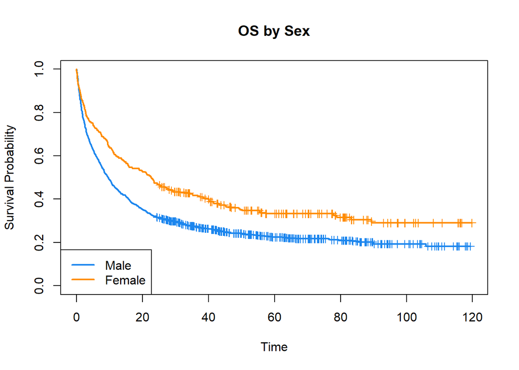

```r
plot(survfit(surv_obj_os ~ lung_data$sex),
     col = c("dodgerblue2", "darkorange"),
     lwd = 2,
     conf.int = FALSE,  # Remove confidence intervals
     xlab = "Time",
     ylab = "Survival Probability",
     main = "OS by Sex",
     mark.time = TRUE)  # Show censoring marks

legend("bottomleft", legend = c("Male", "Female"), col = c("dodgerblue2", "darkorange"), lty = 1, lwd = 2)
```

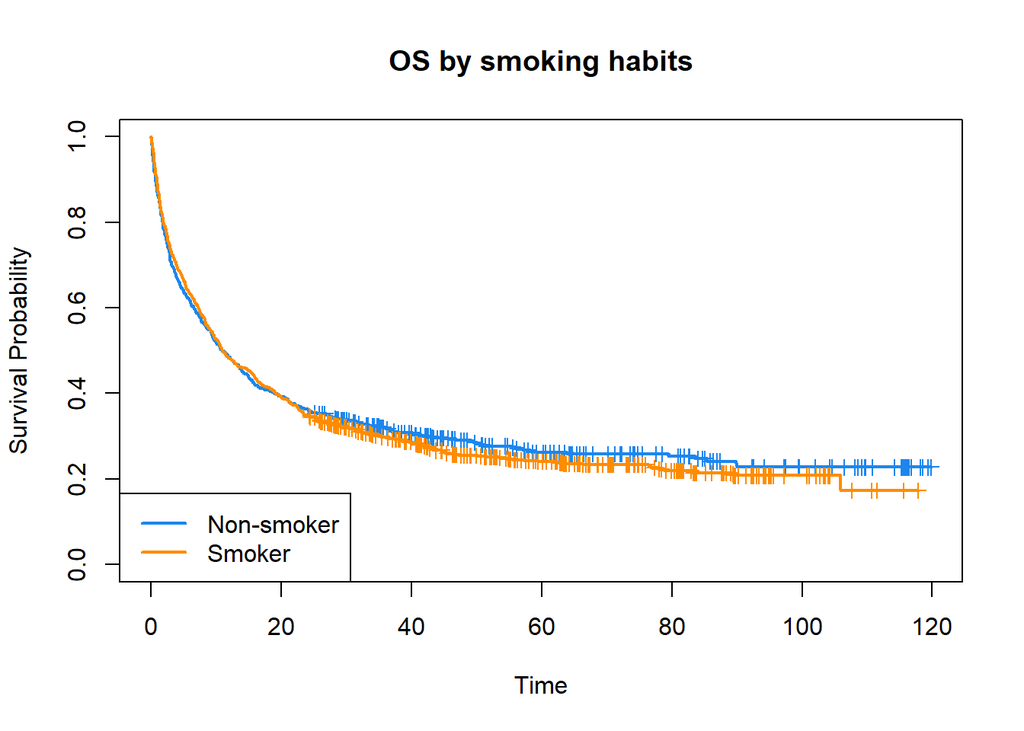

```r
plot(survfit(surv_obj_os ~ lung_data$tobacco),
     col = c("dodgerblue2", "darkorange"),
     lwd = 2,
     conf.int = FALSE,  # Remove confidence intervals
     xlab = "Time",
     ylab = "Survival Probability",
     main = "OS by smoking habits",
     mark.time = TRUE)  # Show censoring marks

legend("bottomleft", legend = c("Non-smoker", "Smoker"), col = c("dodgerblue2", "darkorange"), lty = 1, lwd = 2)
```

```r
summary(fit_os_tobacco)$table # Median OS for smokers and non-smokers
```

```
##             records n.max n.start events    rmean se(rmean)   median  0.95LCL
## tobacco=No      566   566     566    413 38.10631  2.086698 10.90760 9.297741
## tobacco=Yes     885   885     885    667 35.55716  1.640675 10.97331 9.757700
##              0.95UCL
## tobacco=No  13.83162
## tobacco=Yes 13.24025
```

```r
# Custom color palette for age group
age_group_palette <- c("#fca03e", "#ea5739","#ffd700", "#5a8fdc" , "#7cb8d8")
```

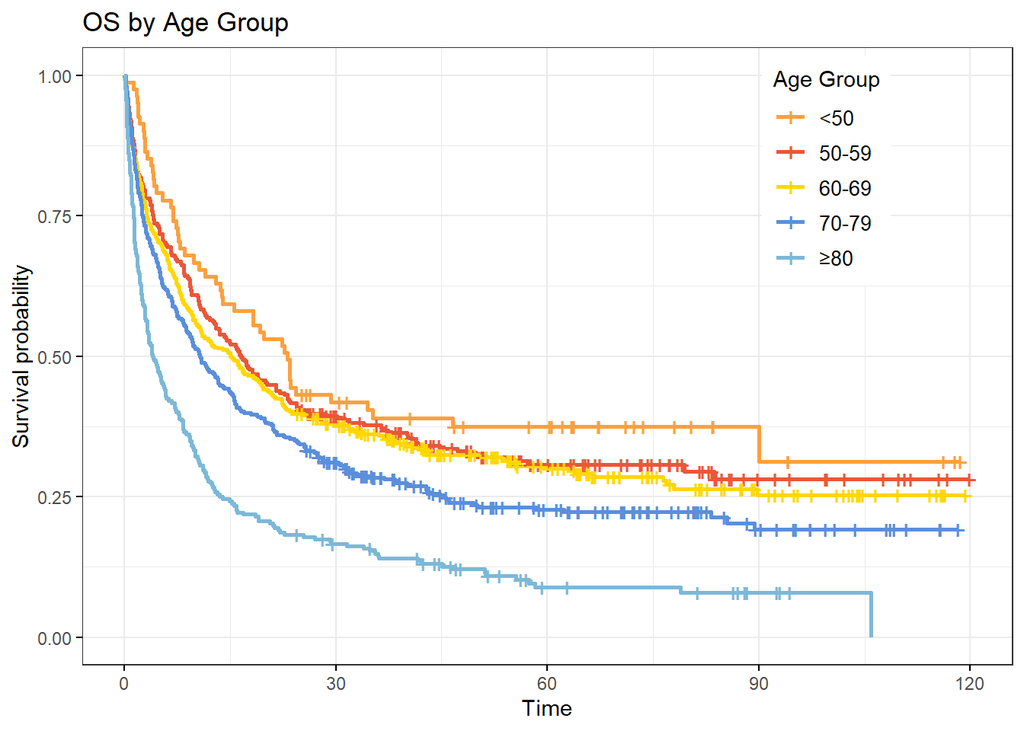

```r
ggsurvplot(fit_os_age_group,
           data = lung_data,
           title = "OS by Age Group",
           legend.labs = c("<50", "50-59", "60-69", "70-79", "≥80"),  # Custom legend labels
           legend.title = "Age Group",
           legend = c(0.8, 0.8),
           palette = age_group_palette,  # Apply the custom palette
           ggtheme = theme_bw() + theme(legend.text = element_text(size = 10),
                                        legend.position = "bottom"))
```

```r
# Custom color palette for morphology
morphology_palette <- c("#b2182b", "#ea5739", "#fca03e", "#ffd700", "#7cb8d8", "#6399c7", "#225ea8")
```

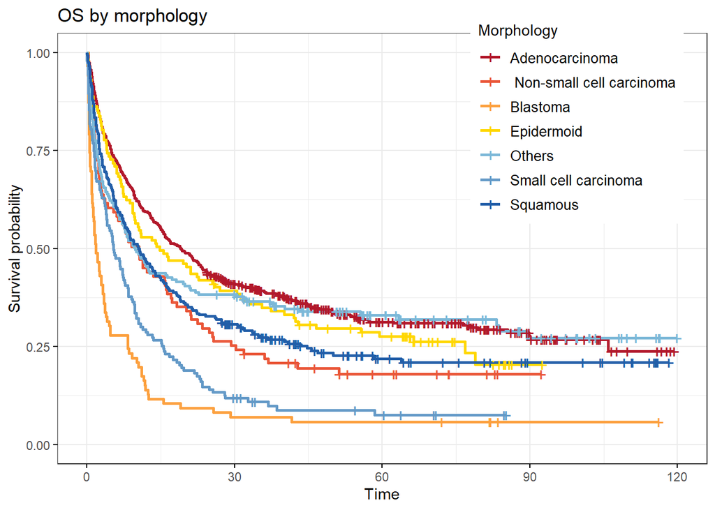

```r
ggsurvplot(fit_os_morf,
           data = lung_data,
           #pval = TRUE,
           title = "OS by morphology",
           legend.labs = levels(factor(lung_data$morphology)),  # Auto-detect labels
           legend.title = "Morphology",
           legend = c(0.8, 0.8),
            palette = morphology_palette,  # Apply the custom palette

           ggtheme = theme_bw() + theme(legend.text = element_text(size = 10),
                                        legend.position = "bottom"))
```

Next, we will perform a log-rank test to see if there is statistical difference in survival over time between groups.

```r
# Perform the log-rank test to compare survival by sex
log_rank_sex <- survdiff(surv_obj_os ~ lung_data$sex)
```

```r
log_rank_sex
```

```
## Call:
## survdiff(formula = surv_obj_os ~ lung_data$sex)
##
##                         N Observed Expected (O-E)^2/E (O-E)^2/V
## lung_data$sex=Male   1122      864      794      6.16      23.4
## lung_data$sex=Female  329      216      286     17.12      23.4
##
##  Chisq= 23.4  on 1 degrees of freedom, p= 1e-06
```

```r
log_rank_tobacco <- survdiff(surv_obj_os ~ lung_data$tobacco)
log_rank_morf <- survdiff(surv_obj_os ~ lung_data$morphology)
log_rank_age_group <- survdiff(surv_obj_os ~ lung_data$age_group)
```

```r
log_rank_tobacco
```

```
## Call:
## survdiff(formula = surv_obj_os ~ lung_data$tobacco)
##
##                         N Observed Expected (O-E)^2/E (O-E)^2/V
## lung_data$tobacco=No  566      413      421    0.1458      0.24
## lung_data$tobacco=Yes 885      667      659    0.0931      0.24
##
##  Chisq= 0.2  on 1 degrees of freedom, p= 0.6
```

```r
log_rank_morf
```

```
## Call:
## survdiff(formula = surv_obj_os ~ lung_data$morphology)
##
##                                                  N Observed Expected (O-E)^2/E
## lung_data$morphology=Adenocarcinoma            571      385    489.2    22.194
## lung_data$morphology= Non-small cell carcinoma  91       74     62.2     2.245
## lung_data$morphology=Blastoma                   86       81     32.0    74.789
## lung_data$morphology=Epidermoid                117       87     96.8     0.983
## lung_data$morphology=Others                    183      125    136.7     0.998
## lung_data$morphology=Small cell carcinoma      143      130     75.1    40.122
## lung_data$morphology=Squamous                  260      198    188.0     0.528
##                                                (O-E)^2/V
## lung_data$morphology=Adenocarcinoma               40.818
## lung_data$morphology= Non-small cell carcinoma     2.390
## lung_data$morphology=Blastoma                     77.729
## lung_data$morphology=Epidermoid                    1.083
## lung_data$morphology=Others                        1.148
## lung_data$morphology=Small cell carcinoma         43.530
## lung_data$morphology=Squamous                      0.641
##
##  Chisq= 144  on 6 degrees of freedom, p= <2e-16
```

```r
log_rank_age_group
```

```
## Call:
## survdiff(formula = surv_obj_os ~ lung_data$age_group)
##
##                             N Observed Expected (O-E)^2/E (O-E)^2/V
## lung_data$age_group=<50    81       51     74.5     7.439     8.014
## lung_data$age_group=50-59 269      183    222.3     6.955     8.786
## lung_data$age_group=60-69 438      305    349.2     5.600     8.305
## lung_data$age_group=70-79 411      314    301.4     0.524     0.729
## lung_data$age_group=>80   252      227    132.5    67.449    77.641
##
##  Chisq= 89  on 4 degrees of freedom, p= <2e-16
```

# Semi-parametric estimation: Cox regression models

Let’s use the Cox Proportional Hazards Model to adjust for potential confounders and quantify the hazard ratio for different groups.

## General Cox model

First, the general cox model that includes all variables:

```r
cox1 <- coxph(surv_obj_os ~ sex + age_group  + tobacco + morphology, data = lung_data, x = TRUE, y = TRUE)
```

```r
summary(cox1)
```

```
## Call:
## coxph(formula = surv_obj_os ~ sex + age_group + tobacco + morphology,
##     data = lung_data, x = TRUE, y = TRUE)
##
##   n= 1451, number of events= 1080
##
##                                         coef exp(coef) se(coef)      z Pr(>|z|)
## sexFemale                           -0.30166   0.73959  0.07990 -3.775  0.00016
## age_group50-59                       0.16951   1.18472  0.15929  1.064  0.28728
## age_group60-69                       0.19024   1.20954  0.15348  1.239  0.21516
## age_group70-79                       0.37496   1.45494  0.15318  2.448  0.01437
## age_group>80                         0.81574   2.26084  0.15795  5.165 2.41e-07
## tobaccoYes                           0.00184   1.00184  0.06353  0.029  0.97689
## morphology Non-small cell carcinoma  0.38304   1.46673  0.12776  2.998  0.00272
## morphologyBlastoma                   0.88491   2.42277  0.13012  6.801 1.04e-11
## morphologyEpidermoid                 0.02131   1.02154  0.12084  0.176  0.86001
## morphologyOthers                     0.16439   1.17867  0.10345  1.589  0.11206
## morphologySmall cell carcinoma       0.77127   2.16252  0.10362  7.443 9.83e-14
## morphologySquamous                   0.19188   1.21153  0.09045  2.121  0.03389
##
## sexFemale                           ***
## age_group50-59
## age_group60-69
## age_group70-79                      *
## age_group>80                        ***
## tobaccoYes
## morphology Non-small cell carcinoma **
## morphologyBlastoma                  ***
## morphologyEpidermoid
## morphologyOthers
## morphologySmall cell carcinoma      ***
## morphologySquamous                  *
## ---
## Signif. codes:  0 '***' 0.001 '**' 0.01 '*' 0.05 '.' 0.1 ' ' 1
##
##                                     exp(coef) exp(-coef) lower .95 upper .95
## sexFemale                              0.7396     1.3521    0.6324     0.865
## age_group50-59                         1.1847     0.8441    0.8670     1.619
## age_group60-69                         1.2095     0.8268    0.8953     1.634
## age_group70-79                         1.4549     0.6873    1.0776     1.964
## age_group>80                           2.2608     0.4423    1.6589     3.081
## tobaccoYes                             1.0018     0.9982    0.8846     1.135
## morphology Non-small cell carcinoma    1.4667     0.6818    1.1418     1.884
## morphologyBlastoma                     2.4228     0.4128    1.8774     3.127
## morphologyEpidermoid                   1.0215     0.9789    0.8061     1.295
## morphologyOthers                       1.1787     0.8484    0.9624     1.444
## morphologySmall cell carcinoma         2.1625     0.4624    1.7650     2.649
## morphologySquamous                     1.2115     0.8254    1.0147     1.447
##
## Concordance= 0.622  (se = 0.009 )
## Likelihood ratio test= 187.9  on 12 df,   p=<2e-16
## Wald test            = 208.5  on 12 df,   p=<2e-16
## Score (logrank) test = 221  on 12 df,   p=<2e-16
```

Let’s save the results into a nice table:

```r
cox1_table <- tbl_regression(cox1, exponentiate = TRUE, label = list(sex~ "Sex", age_group ~ "Age Group", tobacco ~ "Smoking", morphology ~ "Tumor Morphology"))
```

```r
# Save the result table in html

cox1_table %>%
  as_gt() %>%
  gt::gtsave("cox1_results.html")
```

Let’s create a plot of the Hazard Ratios and 95% intervals.

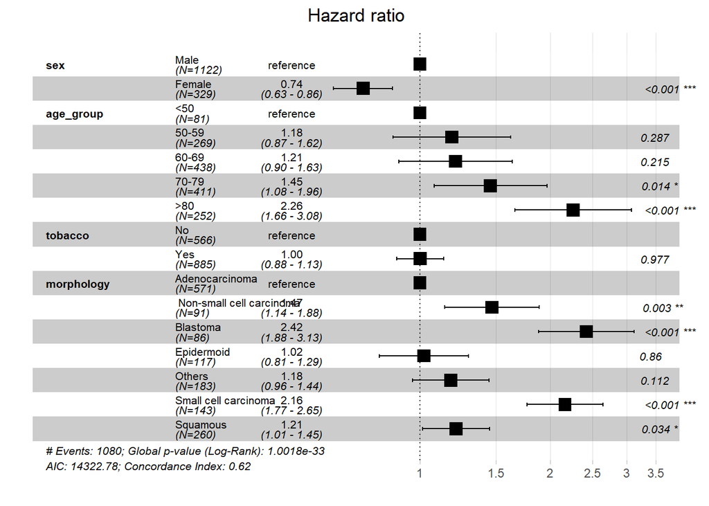

```r
# Create the forest plot
ggforest(cox1, data = lung_data)
```

```r
ggsave("forest_plot.pdf", plot = ggforest(cox1, data = lung_data), width = 12, height = 8)
```

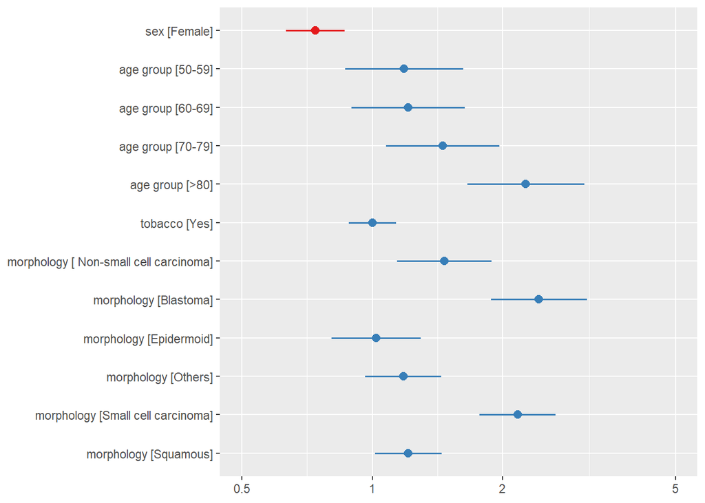

```r
# Forest plot
CI <- exp(confint(cox1))
sjPlot::plot_model(cox1,
                   axis.lim = c(min(CI), max(CI)),
                   auto.label = F)
```

Finally, let’s check that the proportional hazards assumption holds by using the Schoenfeld residuals. If the p-values are large we can assume there is no relation between survival time and the residuals, which implies that the proportional hazard function holds.

```r
head(residuals(cox1, "schoenfeld"))
```

```
##                     sexFemale age_group50-59 age_group60-69 age_group70-79
## 0.0328542094455852 -0.1664071     -0.1423283      0.7530629     -0.2726468
## 0.0328542094455852 -0.1664071     -0.1423283      0.7530629     -0.2726468
## 0.0328542094455852 -0.1664071     -0.1423283      0.7530629     -0.2726468
## 0.0328542094455852  0.8335929     -0.1423283     -0.2469371      0.7273532
## 0.0657084188911704  0.8336970     -0.1426692      0.7545518     -0.2729852
## 0.0657084188911704  0.8336970     -0.1426692      0.7545518     -0.2729852
##                    age_group>80 tobaccoYes morphology Non-small cell carcinoma
## 0.0328542094455852   -0.3048669 -0.6166561                         -0.07013866
## 0.0328542094455852   -0.3048669  0.3833439                         -0.07013866
## 0.0328542094455852   -0.3048669  0.3833439                         -0.07013866
## 0.0328542094455852   -0.3048669  0.3833439                         -0.07013866
## 0.0657084188911704   -0.3055971 -0.6164697                         -0.07030664
## 0.0657084188911704   -0.3055971  0.3835303                         -0.07030664
##                    morphologyBlastoma morphologyEpidermoid morphologyOthers
## 0.0328542094455852         -0.1471921          -0.06607026       -0.1084010
## 0.0328542094455852         -0.1471921          -0.06607026       -0.1084010
## 0.0328542094455852         -0.1471921          -0.06607026       -0.1084010
## 0.0328542094455852         -0.1471921          -0.06607026       -0.1084010
## 0.0657084188911704         -0.1475447          -0.06622849        0.8914411
## 0.0657084188911704         -0.1475447          -0.06622849       -0.1085589
##                    morphologySmall cell carcinoma morphologySquamous
## 0.0328542094455852                      0.8442584         -0.1721648
## 0.0328542094455852                      0.8442584         -0.1721648
## 0.0328542094455852                      0.8442584         -0.1721648
## 0.0328542094455852                     -0.1557416          0.8278352
## 0.0657084188911704                     -0.1542222         -0.1722626
## 0.0657084188911704                     -0.1542222         -0.1722626
```

```r
## Use of function cox.zph
cox.zph(cox1)
```

```
##             chisq df       p
## sex         0.211  1 0.64629
## age_group   2.409  4 0.66108
## tobacco     3.369  1 0.06645
## morphology 24.305  6 0.00046
## GLOBAL     30.466 12 0.00238
```

We can also plot the residuals. We expect it to be a straight line with slope 0.

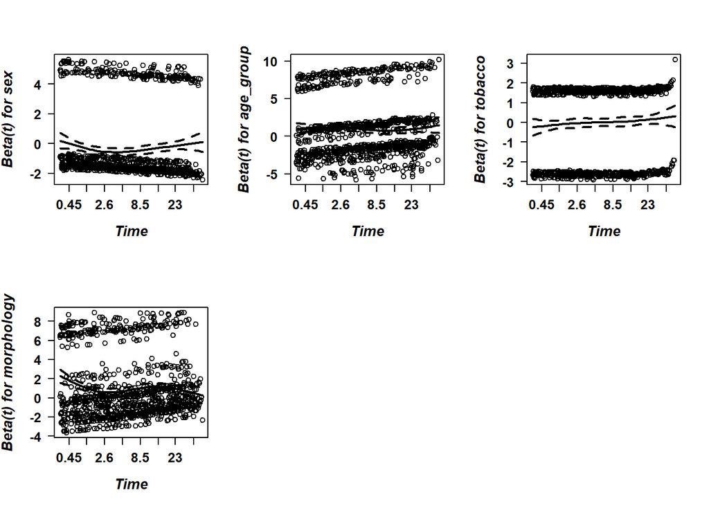

```r
## Use of function plot.cox.zph
par(mfrow = c(2, 3), font = 2, font.lab = 4, font.axis = 2, las = 1,
    cex.lab = 1.3, cex.axis = 1.2)
plot(cox.zph(cox1), lwd = 2)
```

For this general model, the assumption does not hold for the morphology variable, meaning its Hazard Ratio is not constant over time. Stratifying by morphology would solve the issue, but we would not get any insights about the effect of morphology in the survival:

```r
cox_stratified <- coxph(Surv(time_to_event_months, death) ~ sex + age_group + tobacco + strata(morphology), data = lung_data)
```

```r
summary(cox_stratified)
```

```
## Call:
## coxph(formula = Surv(time_to_event_months, death) ~ sex + age_group +
##     tobacco + strata(morphology), data = lung_data)
##
##   n= 1451, number of events= 1080
##
##                     coef exp(coef)  se(coef)      z Pr(>|z|)
## sexFemale      -0.273146  0.760982  0.079967 -3.416 0.000636 ***
## age_group50-59  0.152047  1.164215  0.159479  0.953 0.340387
## age_group60-69  0.163273  1.177358  0.153613  1.063 0.287833
## age_group70-79  0.358149  1.430679  0.153324  2.336 0.019496 *
## age_group>80    0.778535  2.178279  0.158975  4.897 9.72e-07 ***
## tobaccoYes      0.004203  1.004211  0.063631  0.066 0.947341
## ---
## Signif. codes:  0 '***' 0.001 '**' 0.01 '*' 0.05 '.' 0.1 ' ' 1
##
##                exp(coef) exp(-coef) lower .95 upper .95
## sexFemale          0.761     1.3141    0.6506    0.8901
## age_group50-59     1.164     0.8589    0.8517    1.5914
## age_group60-69     1.177     0.8494    0.8713    1.5910
## age_group70-79     1.431     0.6990    1.0593    1.9322
## age_group>80       2.178     0.4591    1.5951    2.9746
## tobaccoYes         1.004     0.9958    0.8865    1.1376
##
## Concordance= 0.569  (se = 0.011 )
## Likelihood ratio test= 64.91  on 6 df,   p=4e-12
## Wald test            = 67.63  on 6 df,   p=1e-12
## Score (logrank) test = 68.62  on 6 df,   p=8e-13
```

```r
cox.zph(cox_stratified)
```

```
##           chisq df    p
## sex       0.925  1 0.34
## age_group 2.877  4 0.58
## tobacco   2.497  1 0.11
## GLOBAL    6.060  6 0.42
```

## Adding interaction terms

When adding an interaction term to a Cox proportional hazards model, we want to test whether the effect of one variable on survival depends on another variable.

Now, let’s add an interaction term sex * tobacco:

```r
cox2 <- coxph(surv_obj_os ~ age_group + morphology + sex*tobacco, data = lung_data)
```

```r
summary(cox2)
```

```
## Call:
## coxph(formula = surv_obj_os ~ age_group + morphology + sex *
##     tobacco, data = lung_data)
##
##   n= 1451, number of events= 1080
##
##                                         coef exp(coef) se(coef)      z Pr(>|z|)
## age_group50-59                       0.17003   1.18534  0.15930  1.067  0.28579
## age_group60-69                       0.18762   1.20637  0.15357  1.222  0.22182
## age_group70-79                       0.37368   1.45307  0.15320  2.439  0.01472
## age_group>80                         0.81321   2.25513  0.15806  5.145 2.68e-07
## morphology Non-small cell carcinoma  0.38271   1.46625  0.12776  2.996  0.00274
## morphologyBlastoma                   0.88683   2.42742  0.13021  6.811 9.72e-12
## morphologyEpidermoid                 0.01968   1.01988  0.12090  0.163  0.87068
## morphologyOthers                     0.16643   1.18108  0.10353  1.607  0.10795
## morphologySmall cell carcinoma       0.77176   2.16357  0.10362  7.448 9.50e-14
## morphologySquamous                   0.19203   1.21171  0.09048  2.122  0.03381
## sexFemale                           -0.34795   0.70613  0.12697 -2.740  0.00614
## tobaccoYes                          -0.01319   0.98689  0.07094 -0.186  0.85245
## sexFemale:tobaccoYes                 0.07450   1.07735  0.15755  0.473  0.63628
##
## age_group50-59
## age_group60-69
## age_group70-79                      *
## age_group>80                        ***
## morphology Non-small cell carcinoma **
## morphologyBlastoma                  ***
## morphologyEpidermoid
## morphologyOthers
## morphologySmall cell carcinoma      ***
## morphologySquamous                  *
## sexFemale                           **
## tobaccoYes
## sexFemale:tobaccoYes
## ---
## Signif. codes:  0 '***' 0.001 '**' 0.01 '*' 0.05 '.' 0.1 ' ' 1
##
##                                     exp(coef) exp(-coef) lower .95 upper .95
## age_group50-59                         1.1853     0.8436    0.8675    1.6197
## age_group60-69                         1.2064     0.8289    0.8928    1.6301
## age_group70-79                         1.4531     0.6882    1.0762    1.9620
## age_group>80                           2.2551     0.4434    1.6544    3.0741
## morphology Non-small cell carcinoma    1.4662     0.6820    1.1415    1.8834
## morphologyBlastoma                     2.4274     0.4120    1.8807    3.1332
## morphologyEpidermoid                   1.0199     0.9805    0.8047    1.2926
## morphologyOthers                       1.1811     0.8467    0.9642    1.4468
## morphologySmall cell carcinoma         2.1636     0.4622    1.7659    2.6508
## morphologySquamous                     1.2117     0.8253    1.0148    1.4468
## sexFemale                              0.7061     1.4162    0.5506    0.9057
## tobaccoYes                             0.9869     1.0133    0.8588    1.1341
## sexFemale:tobaccoYes                   1.0774     0.9282    0.7911    1.4671
##
## Concordance= 0.622  (se = 0.009 )
## Likelihood ratio test= 188.2  on 13 df,   p=<2e-16
## Wald test            = 208.7  on 13 df,   p=<2e-16
## Score (logrank) test = 221.1  on 13 df,   p=<2e-16
```

```r
cox.zph(cox2)
```

```
##              chisq df       p
## age_group    2.438  4 0.65580
## morphology  24.220  6 0.00048
## sex          0.215  1 0.64309
## tobacco      3.256  1 0.07117
## sex:tobacco  2.867  1 0.09042
## GLOBAL      31.367 13 0.00298
```

Now, let’s add an interaction term sex * morphology:

```r
cox_morf <- coxph(surv_obj_os ~ age_group + sex*morphology + tobacco, data = lung_data)
```

```r
summary(cox_morf)
```

```
## Call:
## coxph(formula = surv_obj_os ~ age_group + sex * morphology +
##     tobacco, data = lung_data)
##
##   n= 1451, number of events= 1080
##
##                                                    coef exp(coef)  se(coef)
## age_group50-59                                 0.110156  1.116452  0.161122
## age_group60-69                                 0.134294  1.143729  0.155281
## age_group70-79                                 0.361495  1.435474  0.154534
## age_group>80                                   0.789959  2.203306  0.158763
## sexFemale                                     -0.146075  0.864093  0.109079
## morphology Non-small cell carcinoma            0.437060  1.548148  0.140846
## morphologyBlastoma                             0.928506  2.530726  0.146306
## morphologyEpidermoid                           0.044549  1.045556  0.128677
## morphologyOthers                               0.515133  1.673860  0.114922
## morphologySmall cell carcinoma                 0.746367  2.109324  0.114100
## morphologySquamous                             0.214839  1.239662  0.098655
## tobaccoYes                                    -0.009448  0.990596  0.063655
## sexFemale:morphology Non-small cell carcinoma -0.179810  0.835429  0.347896
## sexFemale:morphologyBlastoma                  -0.159055  0.852949  0.294317
## sexFemale:morphologyEpidermoid                 0.158641  1.171917  0.409620
## sexFemale:morphologyOthers                    -1.441845  0.236491  0.283599
## sexFemale:morphologySmall cell carcinoma       0.586561  1.797795  0.272480
## sexFemale:morphologySquamous                   0.097946  1.102903  0.260088
##                                                    z Pr(>|z|)
## age_group50-59                                 0.684  0.49418
## age_group60-69                                 0.865  0.38712
## age_group70-79                                 2.339  0.01932 *
## age_group>80                                   4.976 6.50e-07 ***
## sexFemale                                     -1.339  0.18052
## morphology Non-small cell carcinoma            3.103  0.00192 **
## morphologyBlastoma                             6.346 2.20e-10 ***
## morphologyEpidermoid                           0.346  0.72919
## morphologyOthers                               4.482 7.38e-06 ***
## morphologySmall cell carcinoma                 6.541 6.10e-11 ***
## morphologySquamous                             2.178  0.02943 *
## tobaccoYes                                    -0.148  0.88201
## sexFemale:morphology Non-small cell carcinoma -0.517  0.60526
## sexFemale:morphologyBlastoma                  -0.540  0.58891
```

[output cut: 35 more lines]

```
## morphologyOthers                                 2.0967
## morphologySmall cell carcinoma                   2.6379
## morphologySquamous                               1.5041
## tobaccoYes                                       1.1222
## sexFemale:morphology Non-small cell carcinoma    1.6521
## sexFemale:morphologyBlastoma                     1.5186
## sexFemale:morphologyEpidermoid                   2.6156
## sexFemale:morphologyOthers                       0.4123
## sexFemale:morphologySmall cell carcinoma         3.0667
## sexFemale:morphologySquamous                     1.8362
##
## Concordance= 0.636  (se = 0.009 )
## Likelihood ratio test= 230.9  on 18 df,   p=<2e-16
## Wald test            = 237.6  on 18 df,   p=<2e-16
## Score (logrank) test = 257.8  on 18 df,   p=<2e-16
```

```r
cox.zph(cox_morf)
```

```
##                chisq df      p
## age_group       2.57  4 0.6326
## sex             1.25  1 0.2629
## morphology     17.41  6 0.0079
## tobacco         2.88  1 0.0896
## sex:morphology  7.53  6 0.2744
## GLOBAL         28.80 18 0.0509
```

Since the morphology has more than 2 categories, an Anova test is needed to see if the interaction is significant:

```r
Anova(cox_morf, type = 3, test = "Wald")
```

```
## Analysis of Deviance Table (Type III tests)
##
## Response: surv_obj_os
##                Df   Chisq Pr(>Chisq)
## age_group       4 65.2111  2.323e-13 ***
## sex             1  1.7934     0.1805
## morphology      6 80.1595  3.312e-15 ***
## tobacco         1  0.0220     0.8820
## sex:morphology  6 35.6162  3.273e-06 ***
## ---
## Signif. codes:  0 '***' 0.001 '**' 0.01 '*' 0.05 '.' 0.1 ' ' 1
```

## Stratifying by sex

In this survival analysis we separate the lung cancer dataset into two different ones: one containing men (sex=1) and the other containing woman (sex=2).

```r
lung_data_men <- read.csv("df_lung_cancer_men.csv")
lung_data_women <- read.csv("df_lung_cancer_women.csv")
```

```r
head(lung_data_men)
```

```
##   patient_id      NHC sex     morphology tobacco age_group time_to_event_days
## 1          3 11734238   1       Squamous      No         5                  8
## 2          6 11943387   1       Squamous      No         4                265
## 3         12 12608694   1 Adenocarcinoma      No         4                152
## 4         22 13535175   1         Others      No         4                 28
## 5         46 13993625   1       Squamous      No         5               1773
## 6         54 14045754   1       Squamous      No         3                555
##   time_to_event_months time_to_event_years death
## 1            0.2628337          0.02190281     1
## 2            8.7063655          0.72553046     1
## 3            4.9938398          0.41615332     1
## 4            0.9199179          0.07665982     1
## 5           58.2505133          4.85420945     1
## 6           18.2340862          1.51950719     1
```

```r
head(lung_data_women)
```

```
##   patient_id      NHC sex     morphology tobacco age_group time_to_event_days
## 1          8 12150847   2 Adenocarcinoma      No         4                829
## 2         53 14035904   2       Squamous      No         5               1429
## 3        237 14101343   2       Blastoma      No         5                139
## 4        281 14201256   2 Adenocarcinoma      No         2               1265
## 5        306 14280022   2       Squamous      No         1                421
## 6        327 15104374   2       Squamous      No         5                 74
##   time_to_event_months time_to_event_years death
## 1            27.236140           2.2696783     1
## 2            46.948665           3.9123888     1
## 3             4.566735           0.3805613     1
## 4            41.560575           3.4633812     1
## 5            13.831622           1.1526352     1
## 6             2.431211           0.2026010     1
```

First we create the surv object:

```r
lung_data_men <- lung_data_men %>%
  mutate(
    age_group = factor(age_group, levels = c(1, 2, 3, 4, 5),
                       labels = c("<50", "50-59", "60-69", "70-79", ">80"))
  )
```

```r
lung_data_women <- lung_data_women %>%
  mutate(
    age_group = factor(age_group, levels = c(1, 2, 3, 4, 5),
                       labels = c("<50", "50-59", "60-69", "70-79", ">80"))
  )
```

```r
surv_obj_men <- Surv(time = lung_data_men$time_to_event_months, event = lung_data_men$death) # For OS
surv_obj_women <- Surv(time = lung_data_women$time_to_event_months, event = lung_data_women$death) # For OS
```

```r
# Kaplan-Meier estimator
km_fit_men <- survfit(surv_obj_men ~ 1)  # ~1 means overall survival without grouping
km_fit_women <- survfit(surv_obj_women ~ 1)
```

Let’s fit the Kaplan-meier estimators for different groups:

```r
# Treat this variables as factors
lung_data_men$morphology <- relevel(factor(lung_data_men$morphology), ref = "Adenocarcinoma")
lung_data_men$tobacco <- as.factor(lung_data_men$tobacco)
lung_data_men$age_group <- as.factor(lung_data_men$age_group)

lung_data_women$morphology <- relevel(factor(lung_data_women$morphology), ref = "Adenocarcinoma")
lung_data_women$tobacco <- as.factor(lung_data_women$tobacco)
lung_data_women$age_group <- as.factor(lung_data_women$age_group)
```

```r
fit_os_morf_men <- survfit(surv_obj_men ~ morphology, data = lung_data_men)
fit_os_tobacco_men <- survfit(surv_obj_men ~ tobacco, data = lung_data_men)
fit_os_age_group_men <- survfit(surv_obj_men ~ age_group, data = lung_data_men)

fit_os_morf_women <- survfit(surv_obj_women ~ morphology, data = lung_data_women)
fit_os_tobacco_women <- survfit(surv_obj_women ~ tobacco, data = lung_data_women)
fit_os_age_group_women <- survfit(surv_obj_women ~ age_group, data = lung_data_women)
```

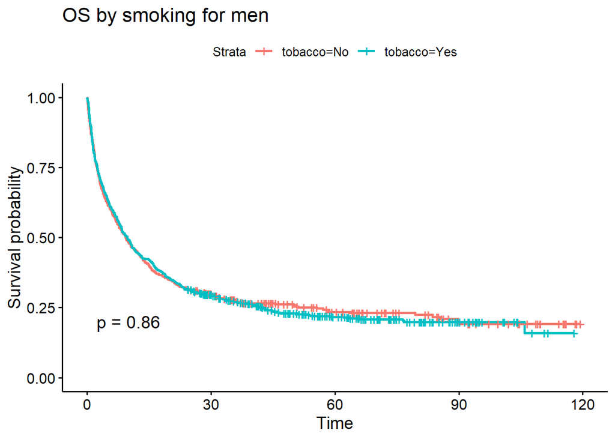

```r
ggsurvplot(fit_os_tobacco_men, data = lung_data_men, pval = TRUE, title = "OS by smoking for men")
```

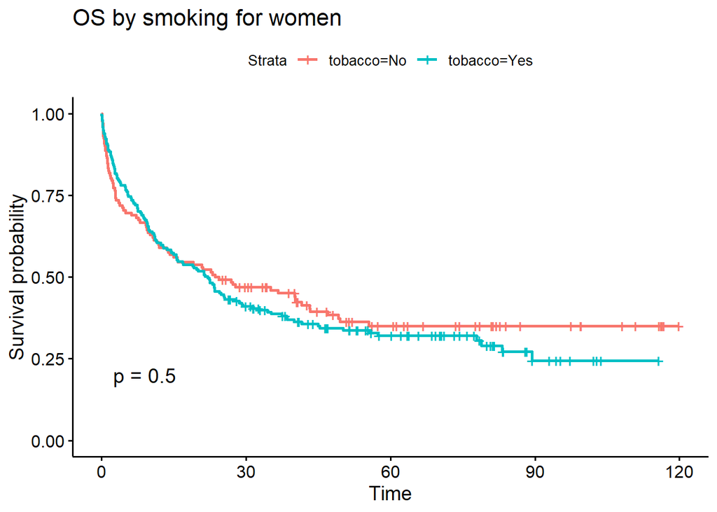

```r
ggsurvplot(fit_os_tobacco_women, data = lung_data_women, pval = TRUE, title = "OS by smoking for women")
```

```r
log_rank_tobacco_men <- survdiff(surv_obj_men ~ lung_data_men$tobacco)
log_rank_tobacco_women <- survdiff(surv_obj_women ~ lung_data_women$tobacco)
```

```r
log_rank_tobacco_men
```

```
## Call:
## survdiff(formula = surv_obj_men ~ lung_data_men$tobacco)
##
##                             N Observed Expected (O-E)^2/E (O-E)^2/V
## lung_data_men$tobacco=No  434      331      333    0.0186    0.0303
## lung_data_men$tobacco=Yes 688      533      531    0.0117    0.0303
##
##  Chisq= 0  on 1 degrees of freedom, p= 0.9
```

```r
log_rank_tobacco_women
```

```
## Call:
## survdiff(formula = surv_obj_women ~ lung_data_women$tobacco)
##
##                               N Observed Expected (O-E)^2/E (O-E)^2/V
## lung_data_women$tobacco=No  132       82     86.9     0.273     0.458
## lung_data_women$tobacco=Yes 197      134    129.1     0.184     0.458
##
##  Chisq= 0.5  on 1 degrees of freedom, p= 0.5
```

```r
cox3 <- coxph(surv_obj_men ~ age_group  + tobacco + morphology, data = lung_data_men)
```

```r
summary(cox3)
```

```
## Call:
## coxph(formula = surv_obj_men ~ age_group + tobacco + morphology,
##     data = lung_data_men)
##
##   n= 1122, number of events= 864
##
##                                         coef exp(coef) se(coef)      z Pr(>|z|)
## age_group50-59                       0.10086   1.10612  0.20000  0.504  0.61405
## age_group60-69                       0.12364   1.13161  0.19239  0.643  0.52045
## age_group70-79                       0.39541   1.48500  0.19174  2.062  0.03918
## age_group>80                         0.79691   2.21868  0.19840  4.017 5.90e-05
## tobaccoYes                          -0.01000   0.99005  0.07104 -0.141  0.88800
## morphology Non-small cell carcinoma  0.43485   1.54473  0.14095  3.085  0.00203
## morphologyBlastoma                   0.91866   2.50593  0.14792  6.211 5.28e-10
## morphologyEpidermoid                 0.04135   1.04221  0.12891  0.321  0.74841
## morphologyOthers                     0.51539   1.67428  0.11505  4.480 7.48e-06
## morphologySmall cell carcinoma       0.73526   2.08602  0.11424  6.436 1.22e-10
## morphologySquamous                   0.20661   1.22950  0.09907  2.085  0.03703
##
## age_group50-59
## age_group60-69
## age_group70-79                      *
## age_group>80                        ***
## tobaccoYes
## morphology Non-small cell carcinoma **
## morphologyBlastoma                  ***
## morphologyEpidermoid
## morphologyOthers                    ***
## morphologySmall cell carcinoma      ***
## morphologySquamous                  *
## ---
## Signif. codes:  0 '***' 0.001 '**' 0.01 '*' 0.05 '.' 0.1 ' ' 1
##
##                                     exp(coef) exp(-coef) lower .95 upper .95
## age_group50-59                          1.106     0.9041    0.7474     1.637
## age_group60-69                          1.132     0.8837    0.7761     1.650
## age_group70-79                          1.485     0.6734    1.0198     2.162
## age_group>80                            2.219     0.4507    1.5039     3.273
## tobaccoYes                              0.990     1.0101    0.8614     1.138
## morphology Non-small cell carcinoma     1.545     0.6474    1.1719     2.036
## morphologyBlastoma                      2.506     0.3991    1.8753     3.349
## morphologyEpidermoid                    1.042     0.9595    0.8095     1.342
## morphologyOthers                        1.674     0.5973    1.3363     2.098
## morphologySmall cell carcinoma          2.086     0.4794    1.6676     2.609
## morphologySquamous                      1.229     0.8133    1.0125     1.493
##
## Concordance= 0.62  (se = 0.01 )
## Likelihood ratio test= 140.5  on 11 df,   p=<2e-16
## Wald test            = 154.8  on 11 df,   p=<2e-16
## Score (logrank) test = 164  on 11 df,   p=<2e-16
```

```r
cox4 <- coxph(surv_obj_women ~ age_group  + tobacco + morphology, data = lung_data_women)
```

```r
summary(cox4)
```

```
## Call:
## coxph(formula = surv_obj_women ~ age_group + tobacco + morphology,
##     data = lung_data_women)
##
##   n= 329, number of events= 216
##
##                                         coef exp(coef) se(coef)      z Pr(>|z|)
## age_group50-59                       0.15379   1.16625  0.27766  0.554 0.579653
## age_group60-69                       0.23292   1.26228  0.27581  0.845 0.398385
## age_group70-79                       0.19146   1.21101  0.27797  0.689 0.490977
## age_group>80                         0.77325   2.16679  0.27113  2.852 0.004345
## tobaccoYes                          -0.01131   0.98875  0.14645 -0.077 0.938419
## morphology Non-small cell carcinoma  0.28190   1.32565  0.32631  0.864 0.387647
## morphologyBlastoma                   0.78062   2.18283  0.27825  2.805 0.005024
## morphologyEpidermoid                 0.18140   1.19890  0.39027  0.465 0.642064
## morphologyOthers                    -0.93269   0.39350  0.26210 -3.559 0.000373
## morphologySmall cell carcinoma       1.32063   3.74578  0.25729  5.133 2.85e-07
## morphologySquamous                   0.32027   1.37749  0.24521  1.306 0.191524
##
## age_group50-59
## age_group60-69
## age_group70-79
## age_group>80                        **
## tobaccoYes
## morphology Non-small cell carcinoma
## morphologyBlastoma                  **
## morphologyEpidermoid
## morphologyOthers                    ***
## morphologySmall cell carcinoma      ***
## morphologySquamous
## ---
## Signif. codes:  0 '***' 0.001 '**' 0.01 '*' 0.05 '.' 0.1 ' ' 1
##
##                                     exp(coef) exp(-coef) lower .95 upper .95
## age_group50-59                         1.1662     0.8575    0.6768    2.0097
## age_group60-69                         1.2623     0.7922    0.7352    2.1673
## age_group70-79                         1.2110     0.8258    0.7023    2.0881
## age_group>80                           2.1668     0.4615    1.2736    3.6864
## tobaccoYes                             0.9887     1.0114    0.7420    1.3175
## morphology Non-small cell carcinoma    1.3256     0.7543    0.6993    2.5130
## morphologyBlastoma                     2.1828     0.4581    1.2652    3.7659
## morphologyEpidermoid                   1.1989     0.8341    0.5579    2.5762
## morphologyOthers                       0.3935     2.5413    0.2354    0.6577
## morphologySmall cell carcinoma         3.7458     0.2670    2.2622    6.2022
## morphologySquamous                     1.3775     0.7260    0.8519    2.2275
##
## Concordance= 0.642  (se = 0.021 )
## Likelihood ratio test= 68.2  on 11 df,   p=3e-10
## Wald test            = 70.46  on 11 df,   p=1e-10
## Score (logrank) test = 80.61  on 11 df,   p=1e-12
```

Let’s summarize both cox results by sex in the same table:

```r
# Create separate regression tables
tbl_men <- tbl_regression(cox3, exponentiate = TRUE, label = list(age_group ~ "Age Group", tobacco ~ "Smoking", morphology ~ "Tumor Morphology")) %>%
  modify_header(label = "**Men**")

tbl_women <- tbl_regression(cox4, exponentiate = TRUE, label = list(age_group ~ "Age Group", tobacco ~ "Smoking", morphology ~ "Tumor Morphology")) %>%
  modify_header(label = "**Women**")

# Merge the tables
tbl_combined <- tbl_merge(
  tbls = list(tbl_men, tbl_women),
  tab_spanner = c("**Men**", "**Women**")
)

# Print the combined table
tbl_combined
```

| **Men** | **Men** **HR** | **Men** **95% CI** | **Men** **p-value** | **Women** **HR** | **Women** **95% CI** | **Women** **p-value** |
| --- | --- | --- | --- | --- | --- | --- |
| Age Group |  |  |  |  |  |  |
| <50 | — | — |  | — | — |  |
| 50-59 | 1.11 | 0.75, 1.64 | 0.6 | 1.17 | 0.68, 2.01 | 0.6 |
| 60-69 | 1.13 | 0.78, 1.65 | 0.5 | 1.26 | 0.74, 2.17 | 0.4 |
| 70-79 | 1.48 | 1.02, 2.16 | 0.039 | 1.21 | 0.70, 2.09 | 0.5 |
| >80 | 2.22 | 1.50, 3.27 | <0.001 | 2.17 | 1.27, 3.69 | 0.004 |
| Smoking |  |  |  |  |  |  |
| No | — | — |  | — | — |  |
| Yes | 0.99 | 0.86, 1.14 | 0.9 | 0.99 | 0.74, 1.32 | >0.9 |
| Tumor Morphology |  |  |  |  |  |  |
| Adenocarcinoma | — | — |  | — | — |  |
| Non-small cell carcinoma | 1.54 | 1.17, 2.04 | 0.002 | 1.33 | 0.70, 2.51 | 0.4 |
| Blastoma | 2.51 | 1.88, 3.35 | <0.001 | 2.18 | 1.27, 3.77 | 0.005 |
| Epidermoid | 1.04 | 0.81, 1.34 | 0.7 | 1.20 | 0.56, 2.58 | 0.6 |
| Others | 1.67 | 1.34, 2.10 | <0.001 | 0.39 | 0.24, 0.66 | <0.001 |
| Small cell carcinoma | 2.09 | 1.67, 2.61 | <0.001 | 3.75 | 2.26, 6.20 | <0.001 |
| Squamous | 1.23 | 1.01, 1.49 | 0.037 | 1.38 | 0.85, 2.23 | 0.2 |

Abbreviations: CI = Confidence Interval, HR = Hazard Ratio

```r
# Save the result table in html

tbl_combined %>%
  as_gt() %>%
  gt::gtsave("cox_sex__results.html")
```

Both models proportional hazard function hold:

```r
cox.zph(cox3)
```

```
##             chisq df    p
## age_group   3.583  4 0.47
## tobacco     0.934  1 0.33
## morphology  9.340  6 0.16
## GLOBAL     13.849 11 0.24
```

```r
cox.zph(cox4)
```

```
##            chisq df    p
## age_group   1.88  4 0.76
## tobacco     2.66  1 0.10
## morphology  9.85  6 0.13
## GLOBAL     12.27 11 0.34
```

# Parametric estimation: Weibull model

```r
weibull_model <- survreg(surv_obj_os ~ sex + age_group + tobacco + morphology, data = lung_data, dist = "weibull")
```

```r
summary(weibull_model)
```

```
##
## Call:
## survreg(formula = surv_obj_os ~ sex + age_group + tobacco + morphology,
##     data = lung_data, dist = "weibull")
##                                       Value Std. Error     z       p
## (Intercept)                          4.2087     0.2587 16.27 < 2e-16
## sexFemale                            0.5498     0.1339  4.11 4.0e-05
## age_group50-59                      -0.3094     0.2669 -1.16  0.2464
## age_group60-69                      -0.3512     0.2572 -1.37  0.1721
## age_group70-79                      -0.6871     0.2566 -2.68  0.0074
## age_group>80                        -1.4896     0.2635 -5.65 1.6e-08
## tobaccoYes                          -0.0290     0.1066 -0.27  0.7853
## morphology Non-small cell carcinoma -0.6993     0.2139 -3.27  0.0011
## morphologyBlastoma                  -1.4822     0.2163 -6.85 7.2e-12
## morphologyEpidermoid                -0.0104     0.2022 -0.05  0.9589
## morphologyOthers                    -0.2161     0.1734 -1.25  0.2127
## morphologySmall cell carcinoma      -1.4150     0.1730 -8.18 2.9e-16
## morphologySquamous                  -0.3400     0.1515 -2.24  0.0248
## Log(scale)                           0.5157     0.0252 20.50 < 2e-16
##
## Scale= 1.67
##
## Weibull distribution
## Loglik(model)= -4396   Loglik(intercept only)= -4501.9
##  Chisq= 211.99 on 12 degrees of freedom, p= 1.1e-38
## Number of Newton-Raphson Iterations: 5
## n= 1451
```

```r
weib_table <- tbl_regression(weibull_model,
                             label = list("sex" = "Sex",
                                          "age_group" = "Age Group",
                                          "tobacco" = "Smoking",
                                          "morphology" = "Tumor Morphology"))
```

```r
## Save the results in a nice format

# Fit Weibull Model
weibull_model <- survreg(Surv(time_to_event_months, death) ~ sex + age_group + tobacco + morphology,
                         data = lung_data, dist = "weibull")

# Create a formatted table
weib_table <- tbl_regression(weibull_model,
                             label = list("sex" = "Sex",
                                          "age_group" = "Age Group",
                                          "tobacco" = "Smoking",
                                          "morphology" = "Tumor Morphology"))

# Convert to a GT table
weib_table_gt <- as_gt(weib_table)

# Save the table as an HTML file
gtsave(weib_table_gt, "weibull_result.html")
```

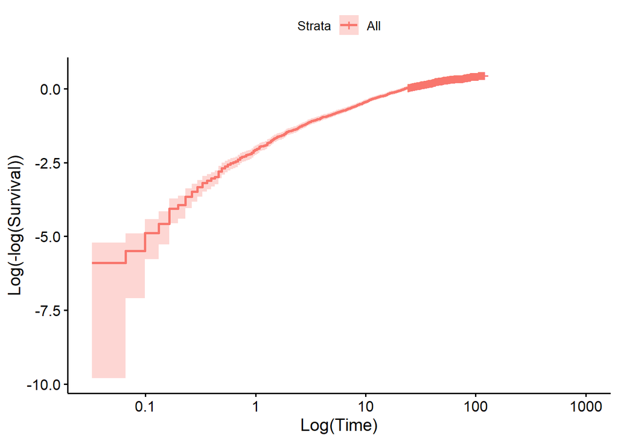

```r
# Fit Kaplan-Meier survival estimate
km_fit_weibull <- survfit(Surv(time_to_event_months, death) ~ 1, data = lung_data)

# Log-log plot for Weibull check
ggsurvplot(km_fit_weibull, fun = "cloglog",
           xlab = "Log(Time)",
           ylab = "Log(-log(Survival))",
           main = "Weibull Assumption Check")
```

```r
# Deviance residuals
deviance_resid <- resid(weibull_model, type = "deviance")
```

```r
# Fitted values (log scale)
predicted_values <- predict(weibull_model, type = "lp")
```

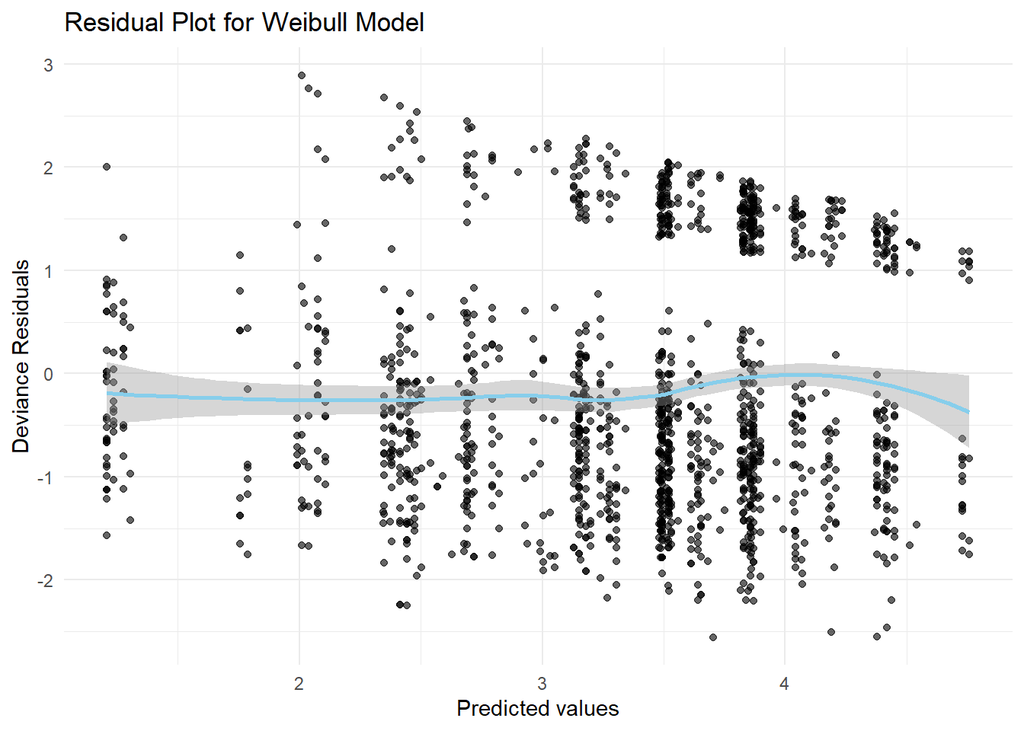

```r
resid_df <- data.frame(
  Predicted = predicted_values,
  Residuals = deviance_resid
)

ggplot(resid_df, aes(x = Predicted, y = Residuals)) +
  geom_point(alpha = 0.6) +
  geom_smooth(method = "loess", se = TRUE, color = "skyblue") +
  xlab("Predicted values") +
  ylab("Deviance Residuals") +
  ggtitle("Residual Plot for Weibull Model") +
  theme_minimal()
```

# Comparative metrics

Compare traditional survival models between them:

```r
# Compare the models using the AIC
AIC(weibull_model, cox1, cox_stratified, cox2, cox_morf)
```

```
##                df       AIC
## weibull_model  14  8819.908
## cox1           12 14322.777
## cox_stratified  6 10567.429
## cox2           13 14324.553
## cox_morf       18 14291.827
```

Calculate C-index and Brier score:

```r
#if (!requireNamespace("BiocManager", quietly = TRUE))
    #install.packages("BiocManager")
```

```r
# BiocManager::install("survcomp")
```

1. C-index for Cox model:

```r
set.seed(42)

# Create 5 stratified folds
folds <- createFolds(lung_data$death, k = 5)

cindex_scores <- c()

for (i in seq_along(folds)) {
  test_idx <- folds[[i]]
  train_data <- lung_data[-test_idx, ] # Select all rows in lung_data except the ones in test_idx
  test_data  <- lung_data[test_idx, ]

  # Fit Cox model with your specified formula
  cox_model <- coxph(Surv(time_to_event_months, death) ~ sex + age_group + tobacco + morphology,
                     data = train_data, x = TRUE, y = TRUE)

  # Predict risk scores (linear predictor) on test fold
  risk_scores <- predict(cox_model, newdata = test_data, type = "lp")

  # Compute C-index for this fold
  c_index <- concordance.index(
    x = risk_scores,
    surv.time = test_data$time_to_event_months,
    surv.event = test_data$death
  )

  cindex_scores <- c(cindex_scores, c_index$c.index)
}

# Report final results
mean_cindex <- mean(cindex_scores)
sd_cindex <- sd(cindex_scores)

cat(sprintf("Cross-validated C-index (Cox): %.3f ± %.3f\n", mean_cindex, sd_cindex))
```

```
## Cross-validated C-index (Cox): 0.616 ± 0.027
```

2. C-index for Weibull model:

```r
set.seed(42)

# Create stratified folds
folds <- createFolds(lung_data$death, k = 5)

cindex_scores <- c()

for (i in seq_along(folds)) {
  test_idx <- folds[[i]]
  train_data <- lung_data[-test_idx, ] # Select all rows in lung_data except the ones in test_idx
  test_data  <- lung_data[test_idx, ]

  # Fit Weibull model on training data
  weibull_model <- survreg(Surv(time_to_event_months, death) ~ sex + age_group + tobacco + morphology,
                         data = train_data, dist = "weibull")

  # Predict expected survival time (log-scale)
  predicted_survival_time <- predict(weibull_model, newdata = test_data, type = "lp")

  # Convert to risk score (lower survival = higher risk ⇒ negate)
  risk_scores <- -predicted_survival_time

  # Compute C-index on test data
  c_index <- concordance.index(
    x = risk_scores,
    surv.time = test_data$time_to_event_months,
    surv.event = test_data$death
  )

  cindex_scores <- c(cindex_scores, c_index$c.index)
}

# Report cross-validated mean ± std
mean_cindex <- mean(cindex_scores)
sd_cindex <- sd(cindex_scores)

cat(sprintf("Cross-validated C-index (Weibull): %.3f ± %.3f\n", mean_cindex, sd_cindex))
```

```
## Cross-validated C-index (Weibull): 0.615 ± 0.026
```

3. Brier Scores and Integrated Brier scores for Cox and Weibull models:

pec() package is used to obtain time-dependent prediction errors like Brier Scores. However, it expects all models to have a method called predictSurvProb(), which gives predicted survival probabilities at a range of times. However, the survreg function (used to fit Weibull) doesn’t have that method by default. Therefore, a custom wrapper function predictSurvProb.survreg() is defined to convert the output of the Weibull model into survival probabilities using the cumulative distribution function of the Weibull distribution. This ensures compatibility with the pec evaluation framework by returning predictions in the required format.

```r
# Custom wrapper function
predictSurvProb.survreg <- function(object, newdata, times, ...) {
  lp <- predict(object, newdata = newdata, type = "lp")
  scale <- object$scale
  dist <- object$dist
  surv_probs <- sapply(times, function(t) {
    1 - pweibull(t, shape = 1/scale, scale = exp(lp))
  })
  if (is.vector(surv_probs)) {
    surv_probs <- matrix(surv_probs, ncol = length(times))
  }
  return(surv_probs)
}
```

```r
# Now we can evaluate both models
pec_results <- pec(
  object = list("Cox" = cox1, "Weibull" = weibull_model),
  formula = Surv(time_to_event_months, death) ~ 1,
  data = lung_data,
  times = 1:70,
  cens.model = "marginal",
  splitMethod = "Boot632",
  B = 100,
  exact = TRUE
)
```

```r
summary(pec_results)
```

```
##
## Prediction error curves
##
##
## Method for estimating the prediction error:
##
## Bootstrap cross-validation
##
## Type: resampling
## Bootstrap sample size:  1451
## No. bootstrap samples:  100
## Sample size:  1451
```

```
##
##  AppErr
##      time n.risk Reference   Cox Weibull
## 1   0.000   1451     0.000 0.000   0.000
## 2   9.347    785     0.248 0.227   0.230
## 3  26.349    483     0.225 0.207   0.209
## 4  53.908    234     0.192 0.178   0.178
## 5 119.819      0     0.034 0.039   0.014
##
##  BootCvErr
##      time n.risk Reference   Cox Weibull
## 1   0.000   1451     0.000 0.000   0.000
## 2   9.347    785     0.249 0.250   0.233
## 3  26.349    483     0.225 0.226   0.213
## 4  53.908    234     0.193 0.194   0.184
## 5 119.819      0        NA 0.035   0.017
##
##  Boot632Err
##      time n.risk Reference   Cox Weibull
## 1   0.000   1451     0.000 0.000   0.000
## 2   9.347    785     0.249 0.241   0.232
## 3  26.349    483     0.225 0.219   0.212
## 4  53.908    234     0.193 0.188   0.182
## 5 119.819      0        NA 0.037   0.016
```

```r
# Integrated Brier Scores (IBS)
ibs_values <- crps(pec_results)
print(ibs_values)
```

```
##
## Integrated Brier score (crps):
##
##           AppErr BootCvErr Boot632Err
## Reference  0.194        NA         NA
## Cox        0.179     0.195      0.189
## Weibull    0.181     0.185      0.183
```

Plot feature importance for Cox and Weibull:

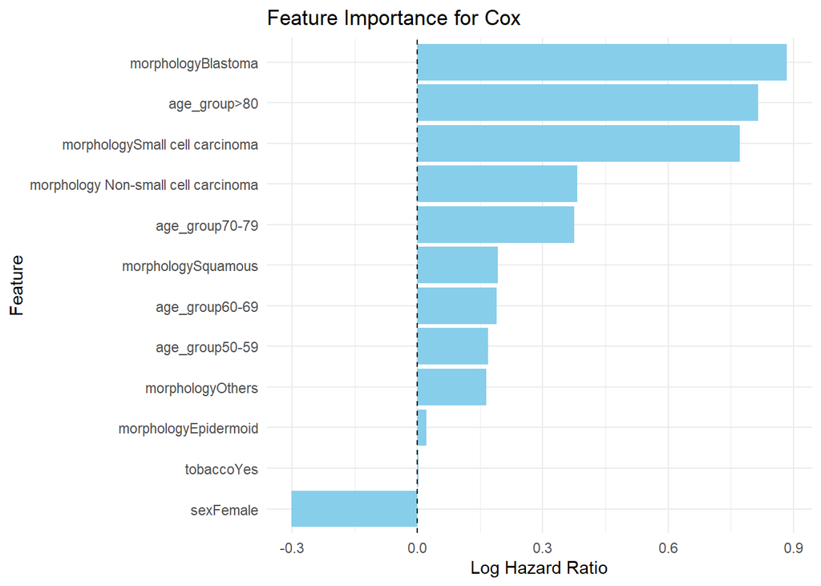

```r
coef_df <- summary(cox1)$coefficients
coef_df <- as.data.frame(coef_df)
coef_df$Variable <- rownames(coef_df)

ggplot(coef_df, aes(x = coef, y = reorder(Variable, coef))) +
  geom_col(fill = "skyblue") +
  geom_vline(xintercept = 0, linetype = "dashed") +
  xlab("Log Hazard Ratio") + ylab("Feature") +
  ggtitle("Feature Importance for Cox") +
  theme_minimal()
```

```r
# Extract coefficients and scale
coef_df <- as.data.frame(summary(weibull_model)$table)
coef_df$Variable <- rownames(coef_df)

# Calculate log hazard ratios: -coef / scale
scale_param <- weibull_model$scale
coef_df$log_HR <- -coef_df$Value / scale_param
```

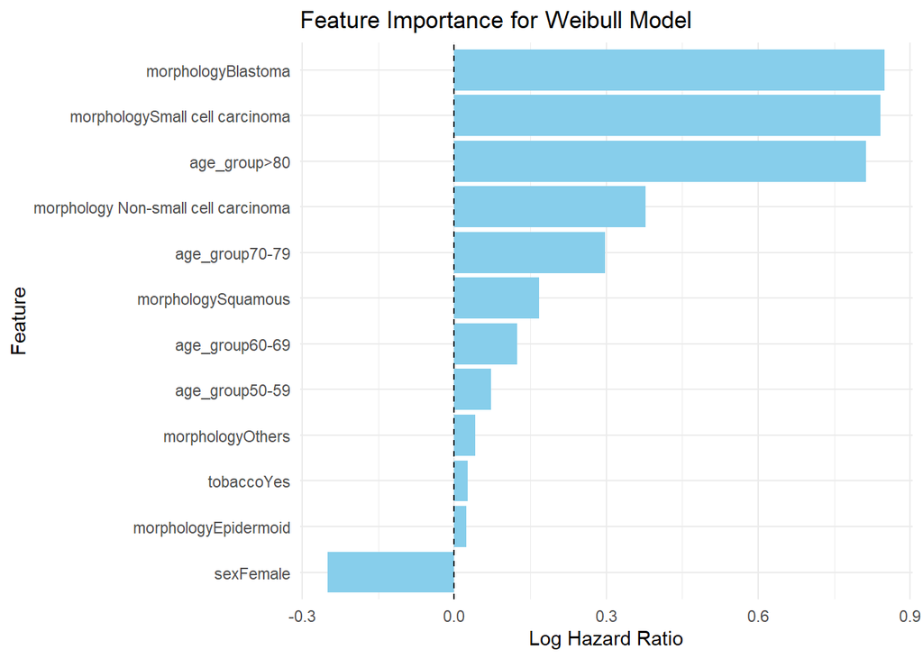

```r
# Remove unwanted rows from the coefficient dataframe
coef_df_clean <- coef_df[!coef_df$Variable %in% c("(Intercept)", "Log(scale)"), ]

ggplot(coef_df_clean, aes(x = log_HR, y = reorder(Variable, log_HR))) +
  geom_col(fill = "skyblue") +
  geom_vline(xintercept = 0, linetype = "dashed") +
  xlab("Log Hazard Ratio") +
  ylab("Feature") +
  ggtitle("Feature Importance for Weibull Model") +
  theme_minimal()
```